# WHITE WINE EDA BY ELAD SHAHAR

# Report overview

This report explores a 2009 dataset containing attributes of 4898 white wines The dataset is related white variants of the Portuguese “Vinho Verde” wine. Due to privacy and logistic issues, only physicochemical (inputs) and sensory (the output) variables are available (e.g. there is no data about grape types, wine brand, wine selling price, etc.).

Input variables (based on physicochemical tests):

1 - fixed acidity (tartaric acid - g / dm^3) 2 - volatile acidity (acetic acid - g / dm^3) 3 - citric acid (g / dm^3) 4 - residual sugar (g / dm^3) 5 - chlorides (sodium chloride - g / dm^3 6 - free sulfur dioxide (mg / dm^3) 7 - total sulfur dioxide (mg / dm^3) 8 - density (g / cm^3) 9 - pH 10 - sulphates (potassium sulphate - g / dm3) 11 - alcohol (% by volume) Output variable (based on sensory data): 12 - quality (score between 0 and 10)

Description of attributes:

1 - fixed acidity: most acids involved with wine or fixed or nonvolatile (do not evaporate readily)

2 - volatile acidity: the amount of acetic acid in wine, which at too high of levels can lead to an unpleasant, vinegar taste

3 - citric acid: found in small quantities, citric acid can add ‘freshness’ and flavor to wines

4 - residual sugar: the amount of sugar remaining after fermentation stops, it’s rare to find wines with less than 1 gram/liter and wines with greater than 45 grams/liter are considered sweet

5 - chlorides: the amount of salt in the wine

6 - free sulfur dioxide: the free form of SO2 exists in equilibrium between molecular SO2 (as a dissolved gas) and bisulfite ion; it prevents microbial growth and the oxidation of wine

7 - total sulfur dioxide: amount of free and bound forms of S02; in low concentrations, SO2 is mostly undetectable in wine, but at free SO2 concentrations over 50 ppm, SO2 becomes evident in the nose and taste of wine

8 - density: the density of water is close to that of water depending on the percent alcohol and sugar content

9 - pH: describes how acidic or basic a wine is on a scale from 0 (very acidic) to 14 (very basic); most wines are between 3-4 on the pH scale

10 - sulphates: a wine additive which can contribute to sulfur dioxide gas (S02) levels, wich acts as an antimicrobial and antioxidant

11 - alcohol: the percent alcohol content of the wine

Output variable: 12 - quality (score between 0 and 10 based on sensory data)

the text file with detailed information on the dataset can be found at this link

# Dataset Analysis

Firstly we will read the data file winequalityWhites.csv and save it to our dataset named wq.

now that we have the datset loaded and saved to wq (wine quality) the first action would be to summerize the dataset. the first 11 attributes include objective tests (eg. PH values) while the last - quality is an output attribute.

Our next step is to run a summary of the dataset to get a grasp on the value range for each of the attributes and other pertinent information

Names contained in the dataset

```
##  [1] "X"                    "fixed.acidity"        "volatile.acidity"
##  [4] "citric.acid"          "residual.sugar"       "chlorides"
##  [7] "free.sulfur.dioxide"  "total.sulfur.dioxide" "density"
## [10] "pH"                   "sulphates"            "alcohol"
## [13] "quality"
```

Dimensions of the dataset

```
## [1] 4898   13
```

Summary of the dataset

```
##        X        fixed.acidity    volatile.acidity  citric.acid
##  Min.   :   1   Min.   : 3.800   Min.   :0.0800   Min.   :0.0000
##  1st Qu.:1225   1st Qu.: 6.300   1st Qu.:0.2100   1st Qu.:0.2700
##  Median :2450   Median : 6.800   Median :0.2600   Median :0.3200
##  Mean   :2450   Mean   : 6.855   Mean   :0.2782   Mean   :0.3342
##  3rd Qu.:3674   3rd Qu.: 7.300   3rd Qu.:0.3200   3rd Qu.:0.3900
##  Max.   :4898   Max.   :14.200   Max.   :1.1000   Max.   :1.6600
##  residual.sugar     chlorides       free.sulfur.dioxide
##  Min.   : 0.600   Min.   :0.00900   Min.   :  2.00
##  1st Qu.: 1.700   1st Qu.:0.03600   1st Qu.: 23.00
##  Median : 5.200   Median :0.04300   Median : 34.00
##  Mean   : 6.391   Mean   :0.04577   Mean   : 35.31
##  3rd Qu.: 9.900   3rd Qu.:0.05000   3rd Qu.: 46.00
##  Max.   :65.800   Max.   :0.34600   Max.   :289.00
##  total.sulfur.dioxide    density             pH          sulphates
##  Min.   :  9.0        Min.   :0.9871   Min.   :2.720   Min.   :0.2200
##  1st Qu.:108.0        1st Qu.:0.9917   1st Qu.:3.090   1st Qu.:0.4100
##  Median :134.0        Median :0.9937   Median :3.180   Median :0.4700
##  Mean   :138.4        Mean   :0.9940   Mean   :3.188   Mean   :0.4898
##  3rd Qu.:167.0        3rd Qu.:0.9961   3rd Qu.:3.280   3rd Qu.:0.5500
##  Max.   :440.0        Max.   :1.0390   Max.   :3.820   Max.   :1.0800
##     alcohol         quality
##  Min.   : 8.00   Min.   :3.000
##  1st Qu.: 9.50   1st Qu.:5.000
##  Median :10.40   Median :6.000
##  Mean   :10.51   Mean   :5.878
##  3rd Qu.:11.40   3rd Qu.:6.000
##  Max.   :14.20   Max.   :9.000
```

Observations We can see some interesting value ranges and will investigate the attributes one by one. We will start with quality as the output attribute.

# Univariate Plots Section

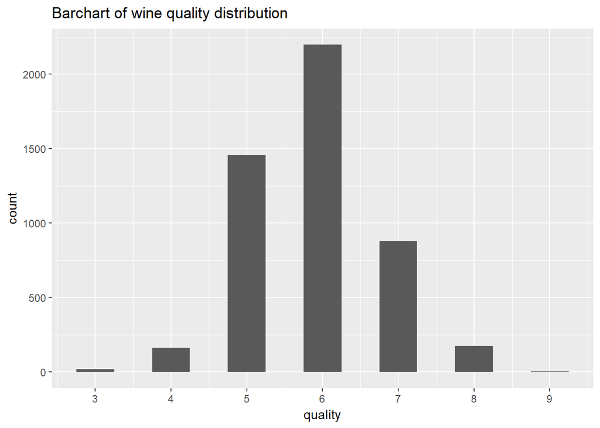

```
##    Min. 1st Qu.  Median    Mean 3rd Qu.    Max.
##   3.000   5.000   6.000   5.878   6.000   9.000
```

```
##
##    3    4    5    6    7    8    9
##   20  163 1457 2198  880  175    5
```

quality is the median of at least 3 evaluations made by wine experts. quality has discrete values (integers) and ranges between 3 and 9. the distribution is largely normal with almost 75% of wines quality scores falling between 5 and 6.

We will cut the quality attribute into group labeled “bad”, “average” and “good”

```
##     Bad Average    Good
##     183    3655    1060
```

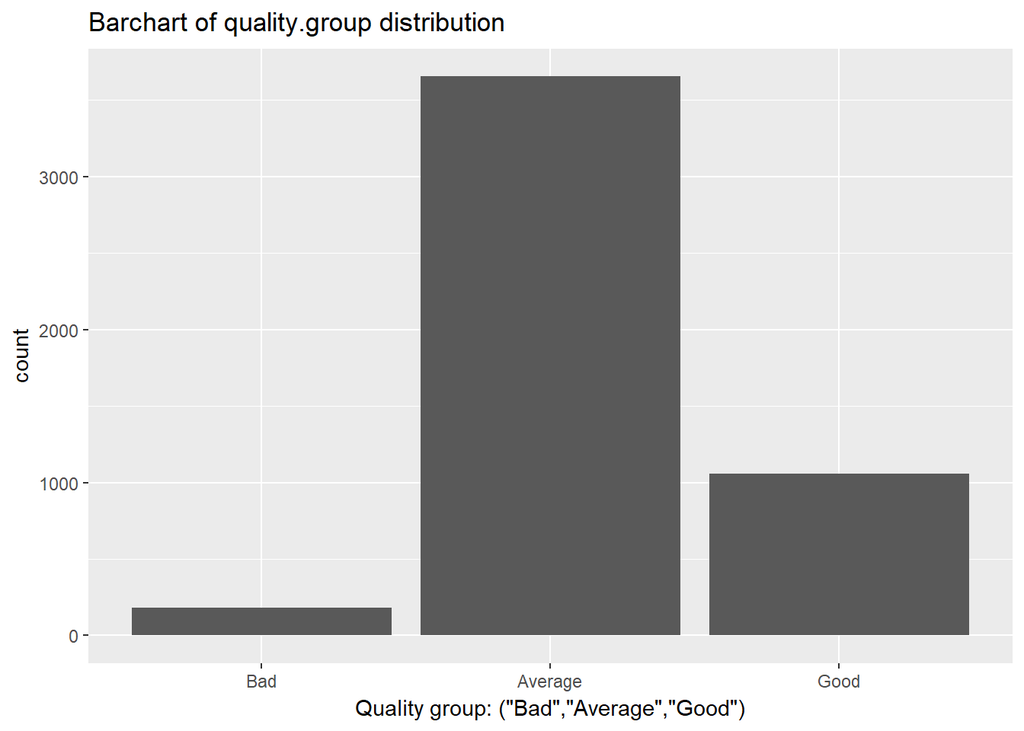

We can see approx. 75% of the wines are with an Average ranking in the plot

## other attributes

### fixed acidity

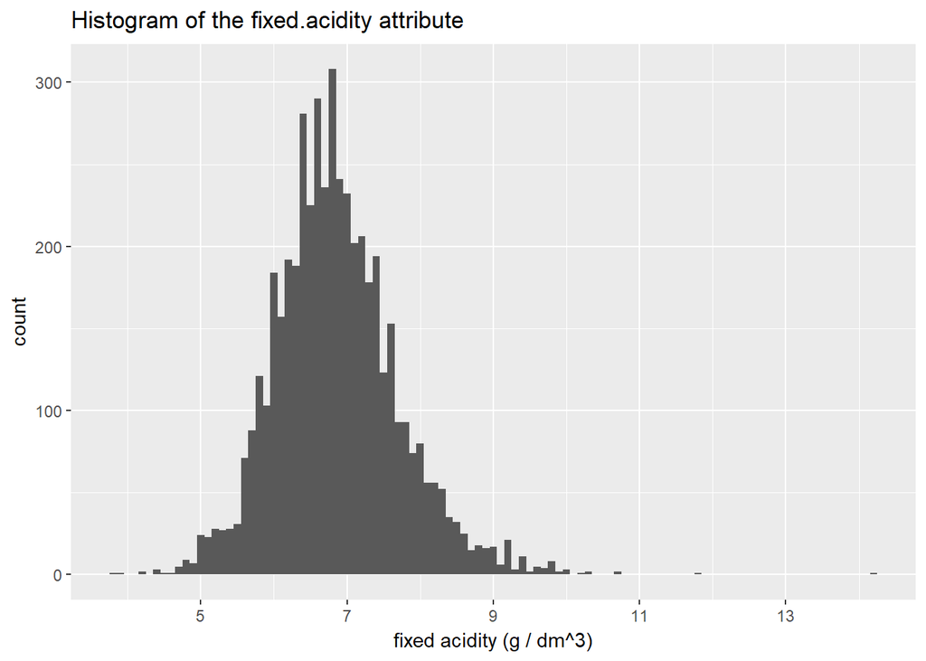

```
##    Min. 1st Qu.  Median    Mean 3rd Qu.    Max.
##   3.800   6.300   6.800   6.855   7.300  14.200
```

We see fixed acidity has a normal-like distribution with the median and mean at 6.8-6.85

### volatile acidity

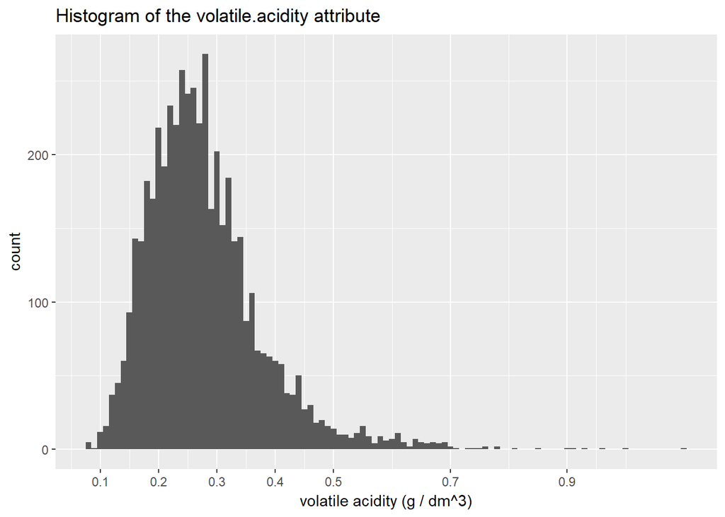

We can see volatile acidity is positively skewed normal-like distribution with some extreme outliers to the right of the chart

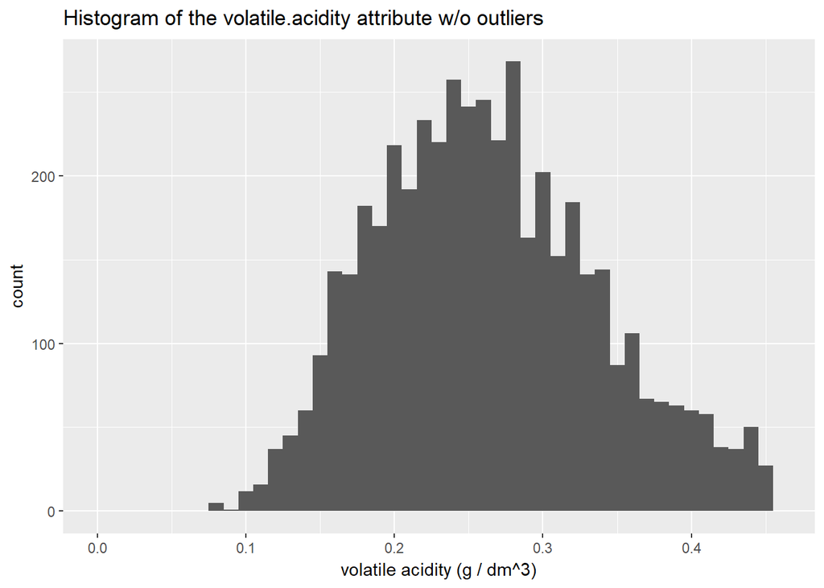

volatile acidity is positvely skewed with most outliers to the right of the curve, when removing the top 5% of results we see a more symmetric distribution

```
##    Min. 1st Qu.  Median    Mean 3rd Qu.    Max.
##  0.0800  0.2100  0.2600  0.2782  0.3200  1.1000
```

We can see volatile acidity is positively skewed normal-like distribution with some extreme outliers to the right of the chart

### citric acid

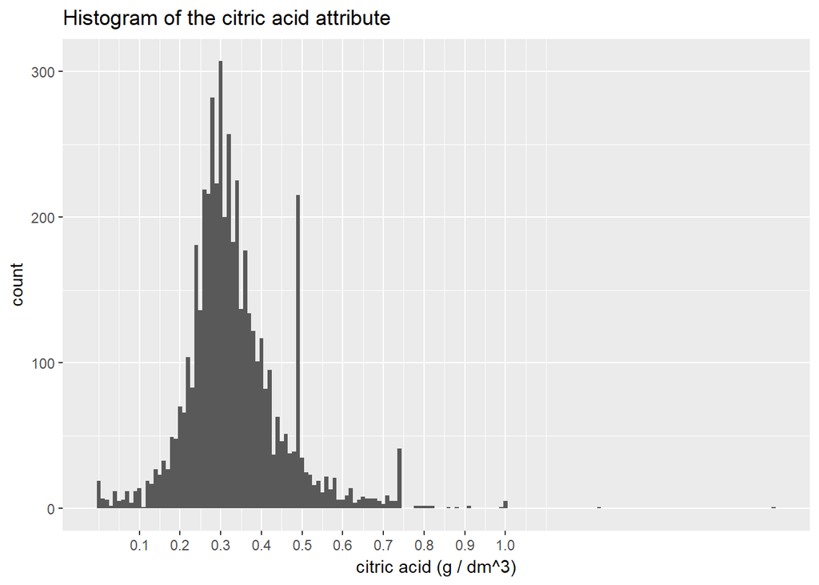

```
##    Min. 1st Qu.  Median    Mean 3rd Qu.    Max.
##  0.0000  0.2700  0.3200  0.3342  0.3900  1.6600
```

We can see citric.acid seems to have a normal distribution with some extreme outliers to the right of the chart, similiar to the distribution of volatile acidity. there is an interesting peak at 0.5g/dm^3 which could suggest some standartization of the amount of citric acid added to wines

citric acid is also the only attribute with 0 values. lets take a look at these values

```
##        X        fixed.acidity   volatile.acidity  citric.acid
##  Min.   : 116   Min.   :4.600   Min.   :0.2600   Min.   :0
##  1st Qu.: 864   1st Qu.:5.250   1st Qu.:0.4025   1st Qu.:0
##  Median :2322   Median :5.800   Median :0.5000   Median :0
##  Mean   :2424   Mean   :5.705   Mean   :0.4966   Mean   :0
##  3rd Qu.:3968   3rd Qu.:6.050   3rd Qu.:0.5950   3rd Qu.:0
##  Max.   :4878   Max.   :7.200   Max.   :0.7850   Max.   :0
##  residual.sugar     chlorides       free.sulfur.dioxide
##  Min.   : 0.800   Min.   :0.02000   Min.   : 7.00
##  1st Qu.: 1.350   1st Qu.:0.03300   1st Qu.:12.50
##  Median : 1.500   Median :0.03700   Median :32.00
##  Mean   : 3.526   Mean   :0.04053   Mean   :28.47
##  3rd Qu.: 6.000   3rd Qu.:0.04500   3rd Qu.:36.00
##  Max.   :13.000   Max.   :0.06500   Max.   :72.00
##  total.sulfur.dioxide    density             pH          sulphates
##  Min.   : 31.0        Min.   :0.9892   Min.   :3.100   Min.   :0.3400
##  1st Qu.: 84.5        1st Qu.:0.9914   1st Qu.:3.265   1st Qu.:0.3800
##  Median :103.0        Median :0.9931   Median :3.310   Median :0.4600
##  Mean   :111.7        Mean   :0.9924   Mean   :3.355   Mean   :0.5026
##  3rd Qu.:148.5        3rd Qu.:0.9938   3rd Qu.:3.405   3rd Qu.:0.6100
##  Max.   :197.0        Max.   :0.9955   Max.   :3.790   Max.   :0.9200
##     alcohol         quality      quality.group
##  Min.   : 8.80   Min.   :4.000   Bad    : 6
##  1st Qu.: 9.90   1st Qu.:4.000   Average:13
##  Median :10.70   Median :5.000   Good   : 0
##  Mean   :10.73   Mean   :5.105
##  3rd Qu.:11.05   3rd Qu.:6.000
##  Max.   :13.80   Max.   :6.000
```

### residual sugar

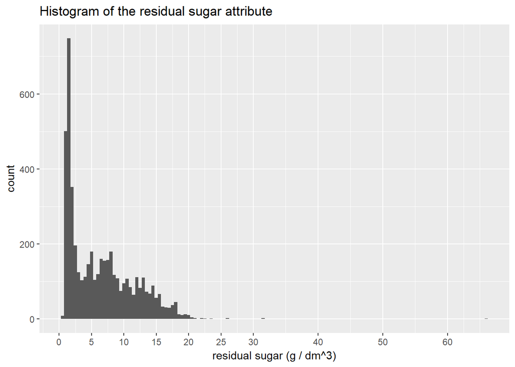

residual sugar has a positively skewed distribution. There are almost no sweet white wines in the dataset as wines are considered sweet with residual sugar over 45g/dm^3. we have only one such wine in the data.

residual sugar seem to have a long tail distribution so we have applied a log10 scale transformation for further investigation.

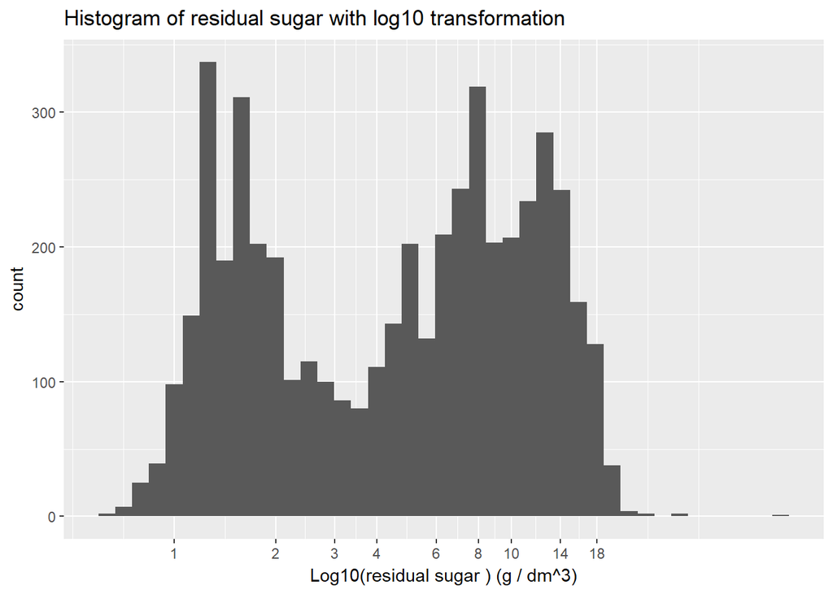

once transformed we can see residual sugar distribution seems bimodal with peaks around 1.25 and 8

```
##    Min. 1st Qu.  Median    Mean 3rd Qu.    Max.
##   0.600   1.700   5.200   6.391   9.900  65.800
```

### Chlorides

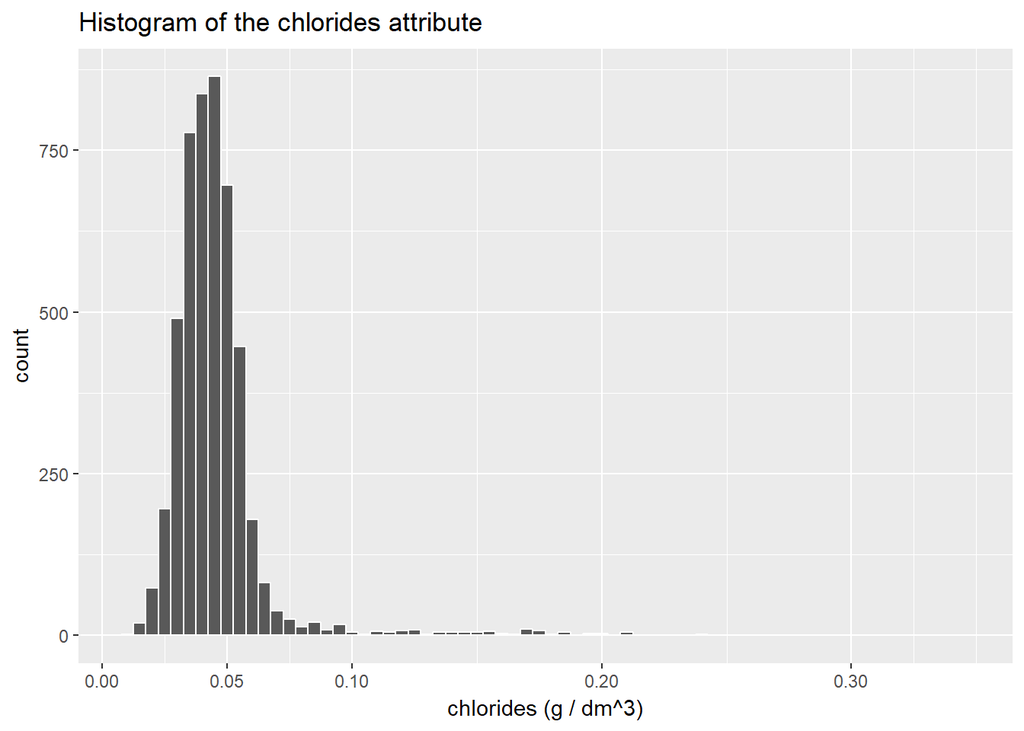

```
##    Min. 1st Qu.  Median    Mean 3rd Qu.    Max.
## 0.00900 0.03600 0.04300 0.04577 0.05000 0.34600
```

chlorides seem to have a long tail distribution so I have applied a log10 scale transformation for further investigation.

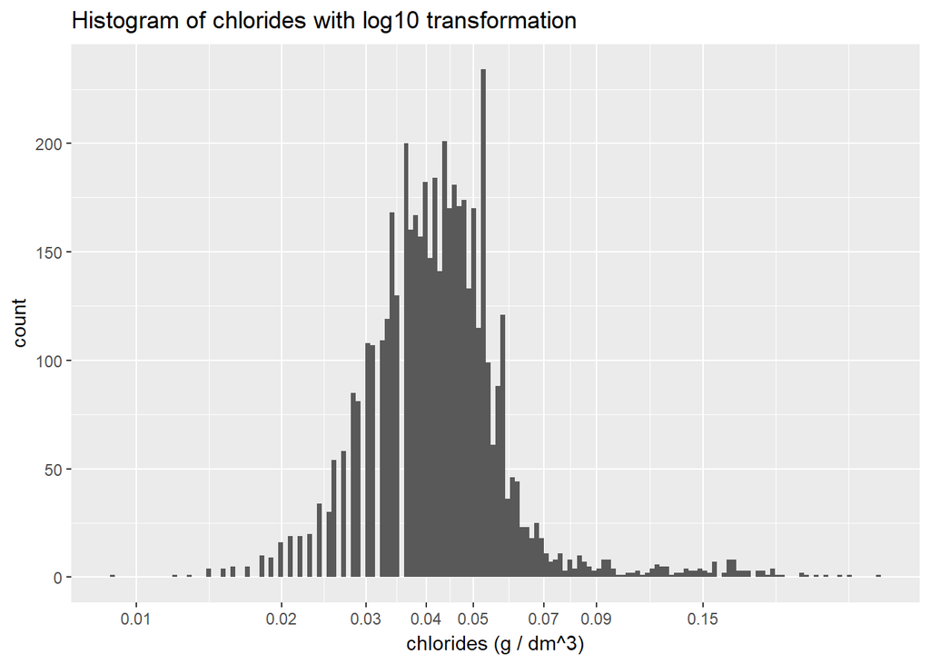

once transformed the distribution seems normal with some outliers to the far right

### free sulfur dioxide

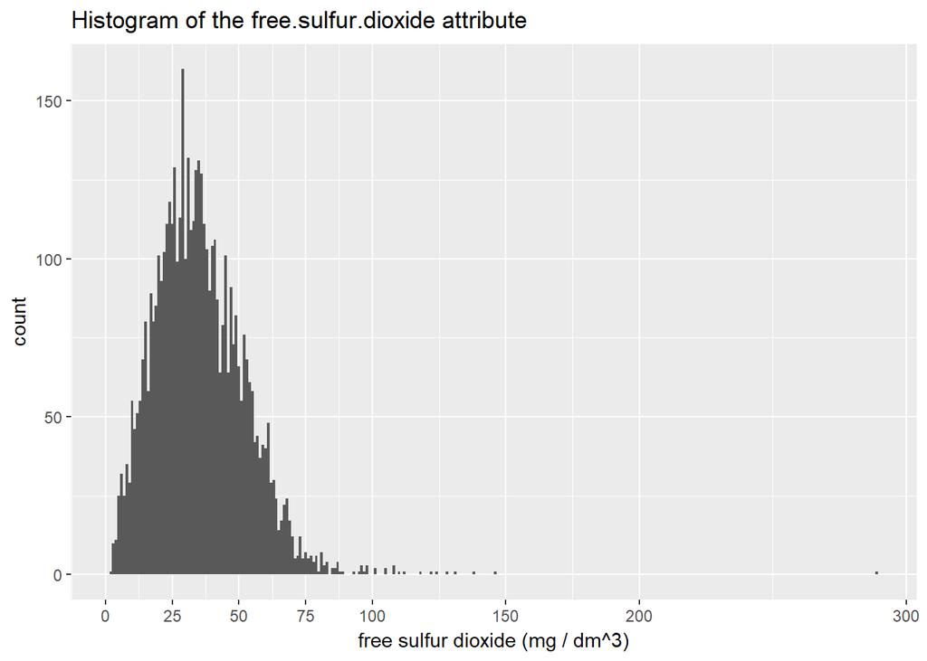

```
##    Min. 1st Qu.  Median    Mean 3rd Qu.    Max.
##    2.00   23.00   34.00   35.31   46.00  289.00
```

The free.sulfur.dioxide distribution seems normal but has however many outliers to the right of the chart. we will look at the plot of the values with the top 5% of the results remove to reduce the effect of outliers

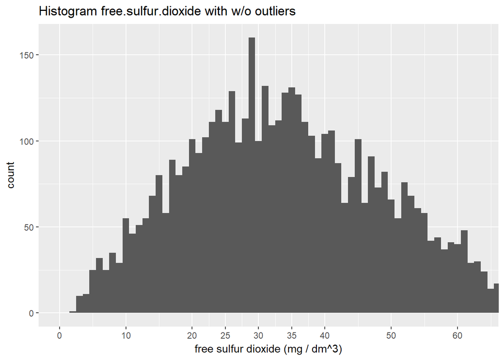

once outliers removed the distribution seems much more symmetrical.

### Total sulfur dioxide

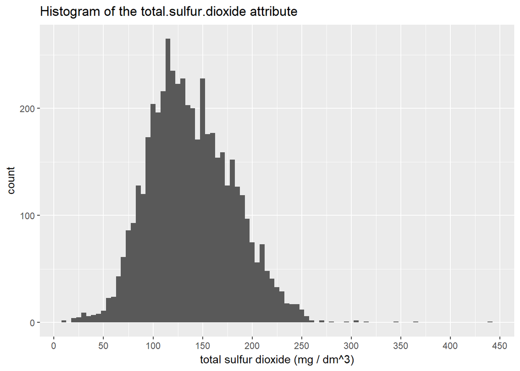

```
##    Min. 1st Qu.  Median    Mean 3rd Qu.    Max.
##     9.0   108.0   134.0   138.4   167.0   440.0
```

total sulfur dioxide has a normal distribution

I will add an attribute sulfur.dioxide.ratio which equals free.sulfur.dioxide / total.sulfur.dioxide

### sulfur dioxide ratio

lets chart the new attribute

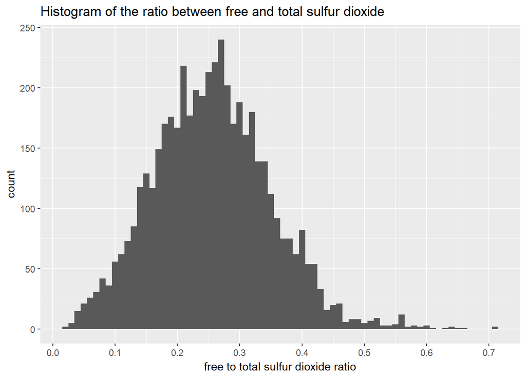

```
##    Min. 1st Qu.  Median    Mean 3rd Qu.    Max.
## 0.02362 0.19093 0.25368 0.25558 0.31579 0.71053
```

it seems that the sulfur dioxide ratio distribution is normal with a long tail to the right of the curve.

### Density

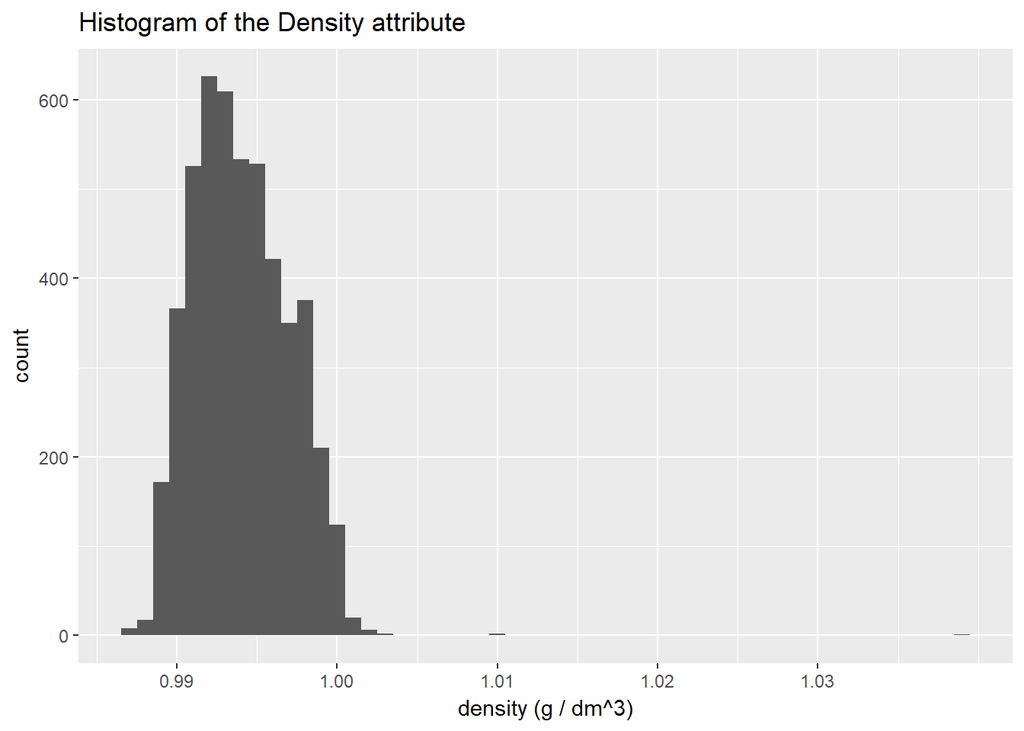

```
##    Min. 1st Qu.  Median    Mean 3rd Qu.    Max.
##  0.9871  0.9917  0.9937  0.9940  0.9961  1.0390
```

Density distribution is normal and narrow. values are clustered between 0.99 to 1 with low variance.

### pH

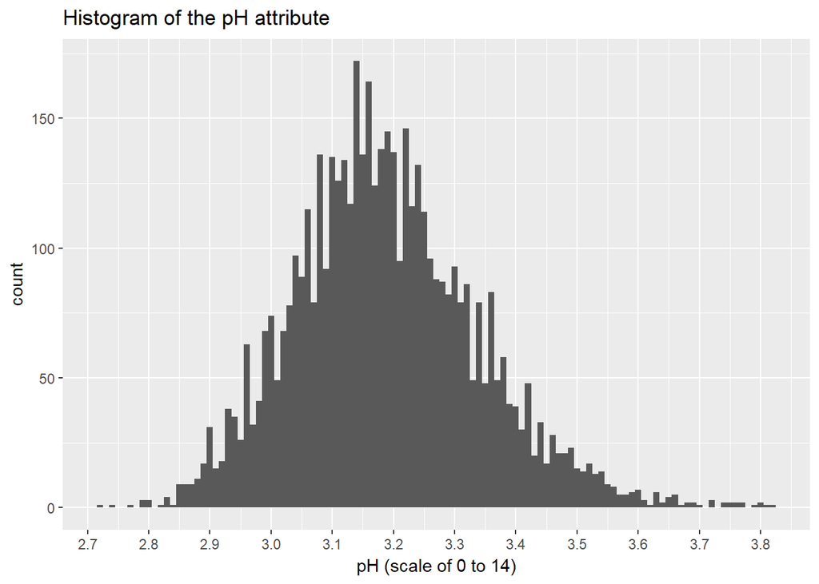

```
##    Min. 1st Qu.  Median    Mean 3rd Qu.    Max.
##   2.720   3.090   3.180   3.188   3.280   3.820
```

pH has a normal distribution

### Sulphates

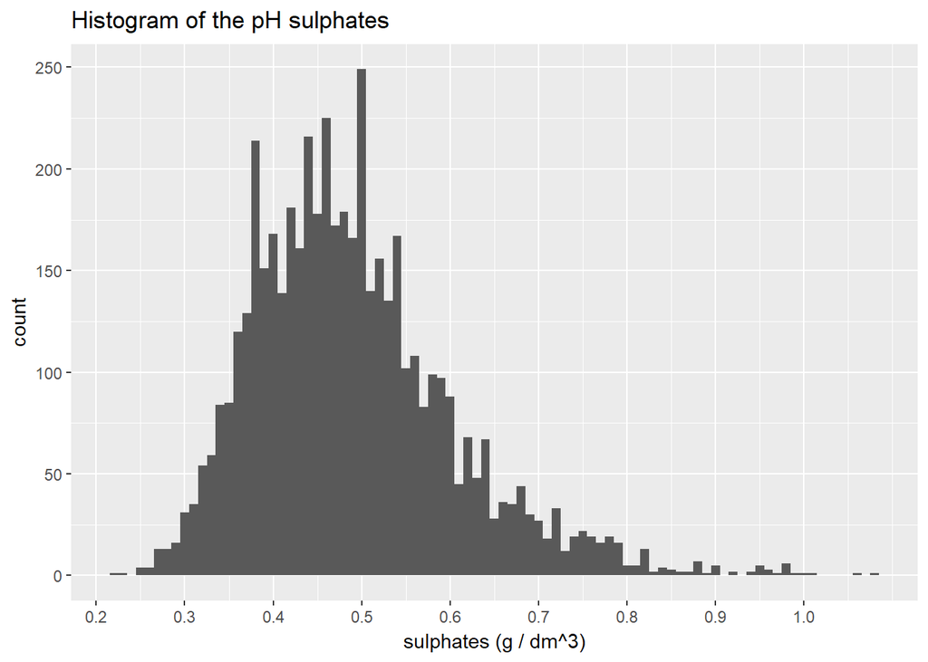

```
##    Min. 1st Qu.  Median    Mean 3rd Qu.    Max.
##  0.2200  0.4100  0.4700  0.4898  0.5500  1.0800
```

sulphates seem positively skewed with a long tail

### Alcohol

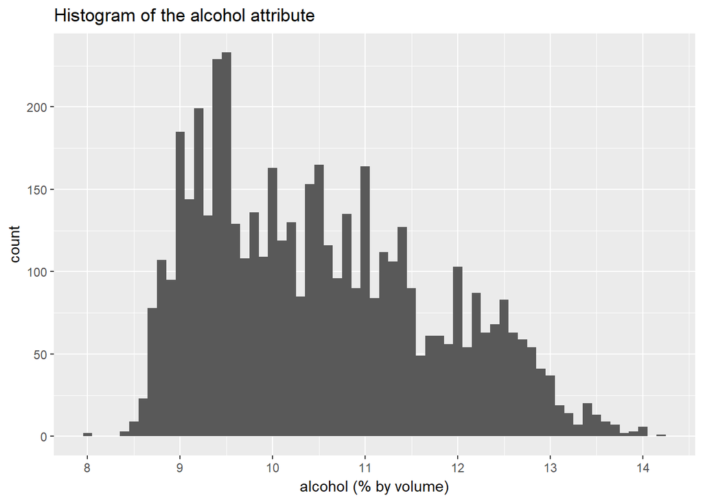

```
##    Min. 1st Qu.  Median    Mean 3rd Qu.    Max.
##    8.00    9.50   10.40   10.51   11.40   14.20
```

alcohol is positively skewed with a long tail. 50% of the wines alcohol level range between 9.5 and 11.4

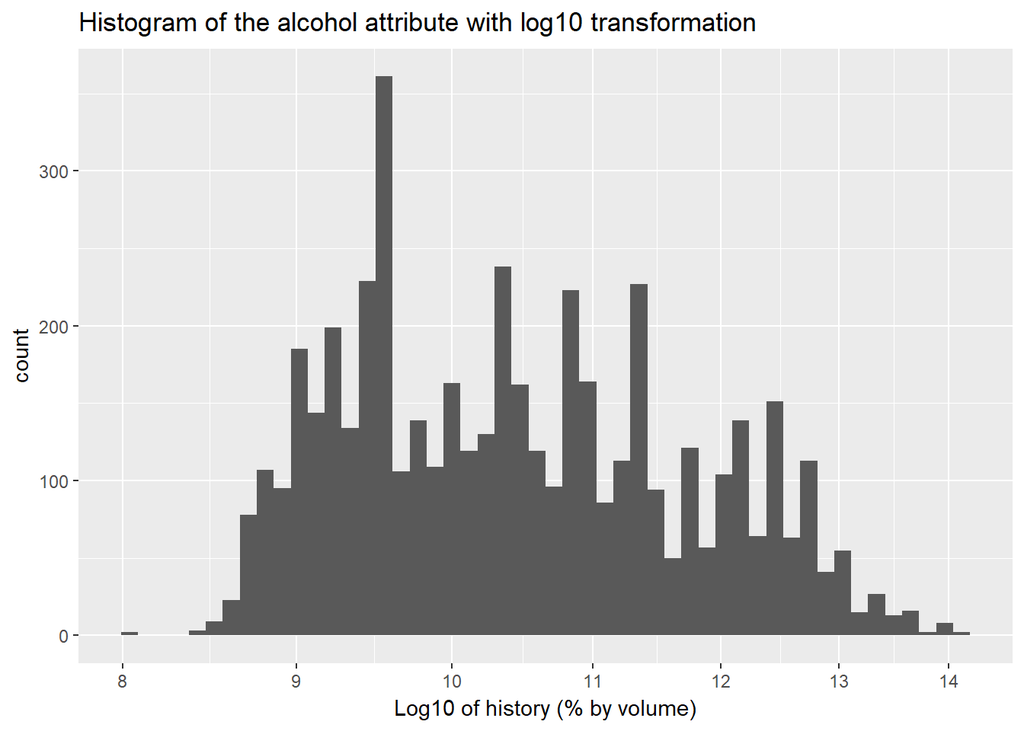

Ive applied a log10 scale x transformation to improve visibilty

# Univariate Analysis

### What is the structure of your dataset?

The dataset is comprised of 4898 observations and 12 attributes. the first 11 attributes include objective tests (eg. PH values) while the last - quality is an output attribute which has discrete values.

### What is/are the main feature(s) of interest in your dataset?

The main feature of interest in our dataset is the wine’s quality. quality is the median of at least 3 evaluations made by wine experts. quality has discrete values (integers) and ranges between 3 and 9. the distribution is largely normal with almost 75% of wines quality scores falling between 5 and 6.

### What other features in the dataset do you think will help support your investigation into your feature(s) of interest?

In my report I will attempt to find an attribute or a combination of attributes with signficant correlation to the quality attribute. the distributions of the attributes in the dataset are largely normal. we will look in more detail into relevant relationships in the Bivariate and Multivariate sections

### Did you create any new variables from existing variables in the dataset?

I created two new variables: 1. sulfur.dioxide.ratio which is the ratio between free.sulfur.dioxide and total.sulfur.dioxide. 2. quality.group which groups the quality values into 3 groups -Wines with quality between 1 and 4 are considered bad quality wine and comrise less than 5% of the total wine observations (there are no actual observations with a quality value lower than 3) -Wines with quality between 5 and 6 are considered average quality wine and comprise almost 75% of the observations -Wines with quality score of 7 or higher are considered good quality wines and comprise approx 21% of the observations (there are no There are no wines with a quality score of 10 - the highest rating)

### Of the features you investigated, were there any unusual distributions? Did you perform any operations on the data to tidy, adjust, or change the form of the data? If so, why did you do this?

I performed multiple operations on the data:  
a. grouping quality values into groups (‘Bad’ , ‘Average’ and ‘Good’)  
b. added a variable of the ratio between free and total sulfur dioxide  
c. in the case of volatile acidity and free sulfur dioxide ive removed the top 5% of observations to reduce the effect of outliers  
d. in the case of residual sugar, Chlorides and Alcohol i’ve performed a scale x log10 transformation in order to better visualize the data

# Bivariate Plots Section

```
##  [1] "X"                    "fixed.acidity"        "volatile.acidity"
##  [4] "citric.acid"          "residual.sugar"       "chlorides"
##  [7] "free.sulfur.dioxide"  "total.sulfur.dioxide" "density"
## [10] "pH"                   "sulphates"            "alcohol"
## [13] "quality"              "quality.group"        "sulfur.dioxide.ratio"
```

```
##  [1] "fixed.acidity"        "volatile.acidity"     "citric.acid"
##  [4] "residual.sugar"       "chlorides"            "free.sulfur.dioxide"
##  [7] "total.sulfur.dioxide" "density"              "pH"
## [10] "sulphates"            "alcohol"              "quality"
```

```
##                      fixed.acidity volatile.acidity citric.acid
## fixed.acidity                 1.00            -0.02        0.29
## volatile.acidity             -0.02             1.00       -0.15
## citric.acid                   0.29            -0.15        1.00
## residual.sugar                0.09             0.06        0.09
## chlorides                     0.02             0.07        0.11
## free.sulfur.dioxide          -0.05            -0.10        0.09
## total.sulfur.dioxide          0.09             0.09        0.12
## density                       0.27             0.03        0.15
## pH                           -0.43            -0.03       -0.16
## sulphates                    -0.02            -0.04        0.06
## alcohol                      -0.12             0.07       -0.08
## quality                      -0.11            -0.19       -0.01
##                      residual.sugar chlorides free.sulfur.dioxide
## fixed.acidity                  0.09      0.02               -0.05
## volatile.acidity               0.06      0.07               -0.10
## citric.acid                    0.09      0.11                0.09
## residual.sugar                 1.00      0.09                0.30
## chlorides                      0.09      1.00                0.10
## free.sulfur.dioxide            0.30      0.10                1.00
## total.sulfur.dioxide           0.40      0.20                0.62
## density                        0.84      0.26                0.29
## pH                            -0.19     -0.09                0.00
## sulphates                     -0.03      0.02                0.06
## alcohol                       -0.45     -0.36               -0.25
## quality                       -0.10     -0.21                0.01
##                      total.sulfur.dioxide density    pH sulphates alcohol
## fixed.acidity                        0.09    0.27 -0.43     -0.02   -0.12
## volatile.acidity                     0.09    0.03 -0.03     -0.04    0.07
## citric.acid                          0.12    0.15 -0.16      0.06   -0.08
## residual.sugar                       0.40    0.84 -0.19     -0.03   -0.45
## chlorides                            0.20    0.26 -0.09      0.02   -0.36
## free.sulfur.dioxide                  0.62    0.29  0.00      0.06   -0.25
## total.sulfur.dioxide                 1.00    0.53  0.00      0.13   -0.45
## density                              0.53    1.00 -0.09      0.07   -0.78
## pH                                   0.00   -0.09  1.00      0.16    0.12
## sulphates                            0.13    0.07  0.16      1.00   -0.02
## alcohol                             -0.45   -0.78  0.12     -0.02    1.00
## quality                             -0.17   -0.31  0.10      0.05    0.44
##                      quality
## fixed.acidity          -0.11
## volatile.acidity       -0.19
## citric.acid            -0.01
## residual.sugar         -0.10
## chlorides              -0.21
## free.sulfur.dioxide     0.01
## total.sulfur.dioxide   -0.17
## density                -0.31
## pH                      0.10
## sulphates               0.05
## alcohol                 0.44
## quality                 1.00
```

It is very hard to see the higher values in this output, we will use pairs() out of psych package to visulaize. in addition we will remove the added variable sulfur.dioxide.ratio as there seem to be no signficiant correlations for this variable with other attribute except for free sulfur dioxide

### Pairs Matrix

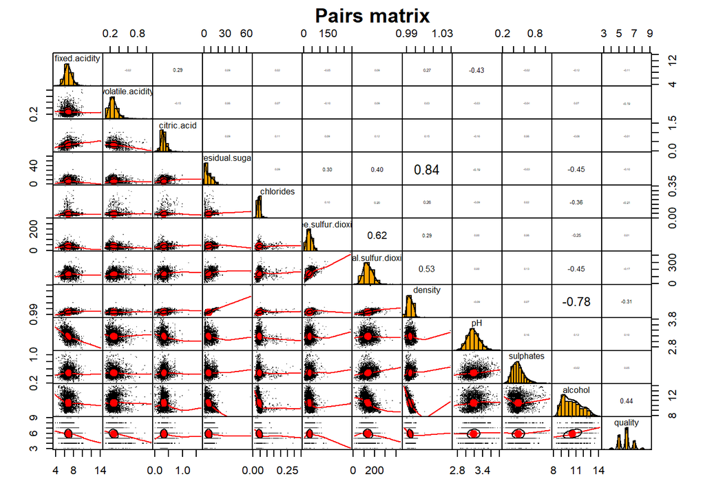

we will run another correlation matix

### Correlation Matrix

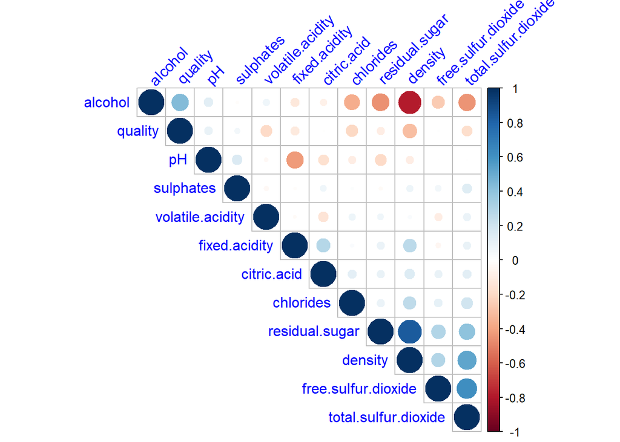

The second correlation matrix shows the same relationships as our pairs plot. I will continue to investigate the signficant relationships we discovered starting with quality correlation to each other attribute and moving on to the most significant relationships we discovered between density, residual sugar, alcohol and total sulfur dioxide.

## Investigating the main interest attribute - quality

### quality to fixed acidity

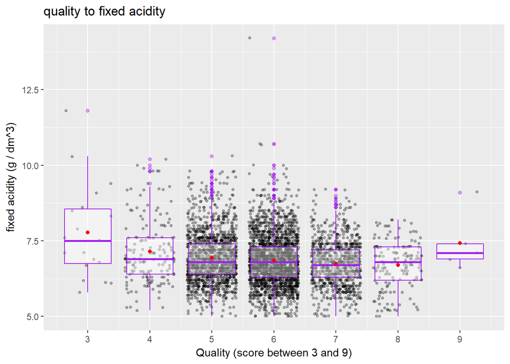

```
##
##  Pearson's product-moment correlation
##
## data:  quality and fixed.acidity
## t = -8.005, df = 4896, p-value = 1.48e-15
## alternative hypothesis: true correlation is not equal to 0
## 95 percent confidence interval:
##  -0.14121974 -0.08592991
## sample estimates:
##        cor
## -0.1136628
```

### quality to volatile acidity

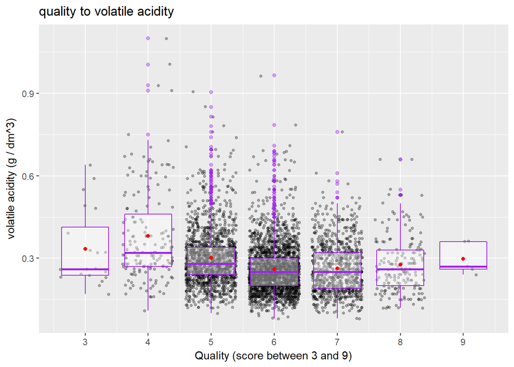

```
##
##  Pearson's product-moment correlation
##
## data:  quality and volatile.acidity
## t = -13.891, df = 4896, p-value < 2.2e-16
## alternative hypothesis: true correlation is not equal to 0
## 95 percent confidence interval:
##  -0.2215214 -0.1676307
## sample estimates:
##       cor
## -0.194723
```

A weak negative correlation between quality and volatile acidity. wines in the “good”" category seem to have slightly lower average acidity while wines in the “bad”" category seem to have slightly higher average acidity. Wines with quality grade 9 seem to behave against the trend but there are very few observations with quality 9 in the dataset so nothing conclusive.

### quality to citric acid

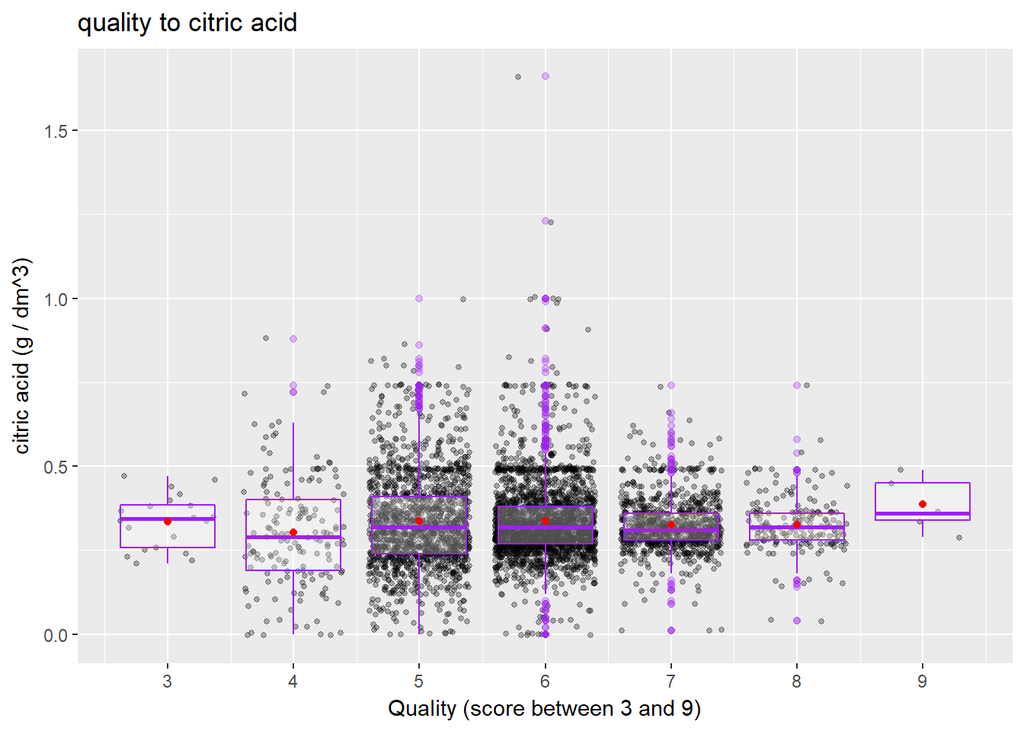

```
##
##  Pearson's product-moment correlation
##
## data:  quality and citric.acid
## t = -0.6444, df = 4896, p-value = 0.5193
## alternative hypothesis: true correlation is not equal to 0
## 95 percent confidence interval:
##  -0.03720595  0.01880221
## sample estimates:
##          cor
## -0.009209091
```

No clear correlation between quality and citric acid

### quality to residual sugar

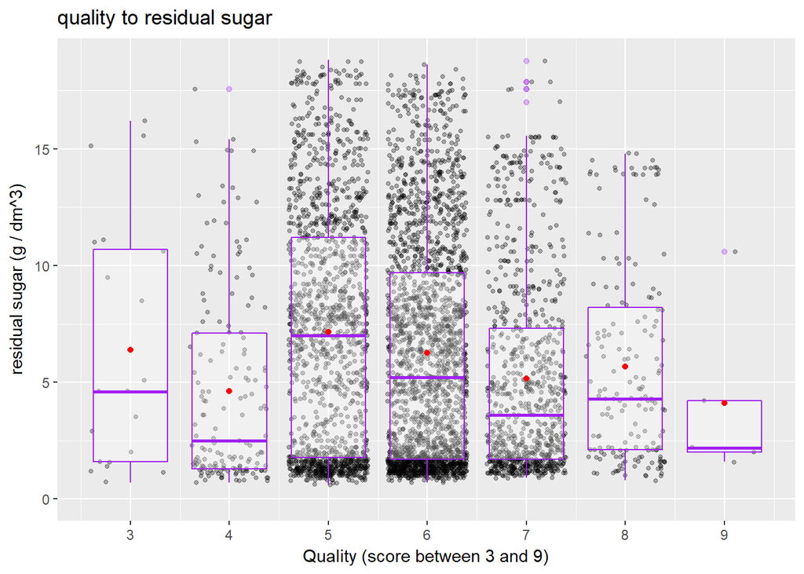

```
##
##  Pearson's product-moment correlation
##
## data:  quality and residual.sugar
## t = -6.8603, df = 4896, p-value = 7.724e-12
## alternative hypothesis: true correlation is not equal to 0
## 95 percent confidence interval:
##  -0.12524103 -0.06976101
## sample estimates:
##         cor
## -0.09757683
```

I removed the top 1% of residual sugar results to reduce outlier effect and make the plot more readable. No clear correlation between quality and residual sugar.

### quality to chlorides

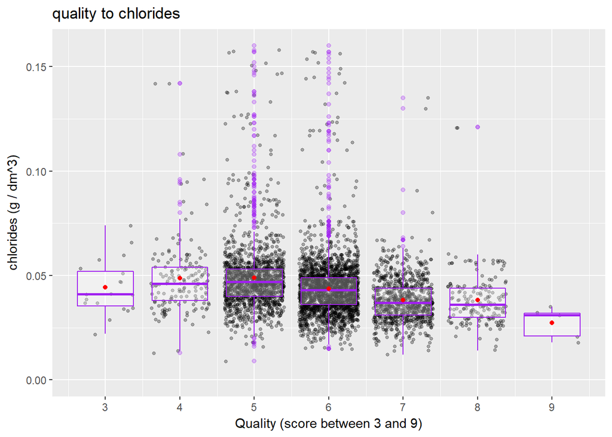

```
##
##  Pearson's product-moment correlation
##
## data:  quality and chlorides
## t = -15.024, df = 4896, p-value < 2.2e-16
## alternative hypothesis: true correlation is not equal to 0
## 95 percent confidence interval:
##  -0.2365501 -0.1830039
## sample estimates:
##        cor
## -0.2099344
```

I removed the top 1% of chlorides results to reduce outlier effect and make the plot more readable. We can see a weak correlation between quality and chlorides where on average better quality wines have lower chlorides values. wines in the “bad”" category (3 to 4) do not uphold the trend but the number of “bad”" quality observations is very small.

### quality to free sulfur dioxide

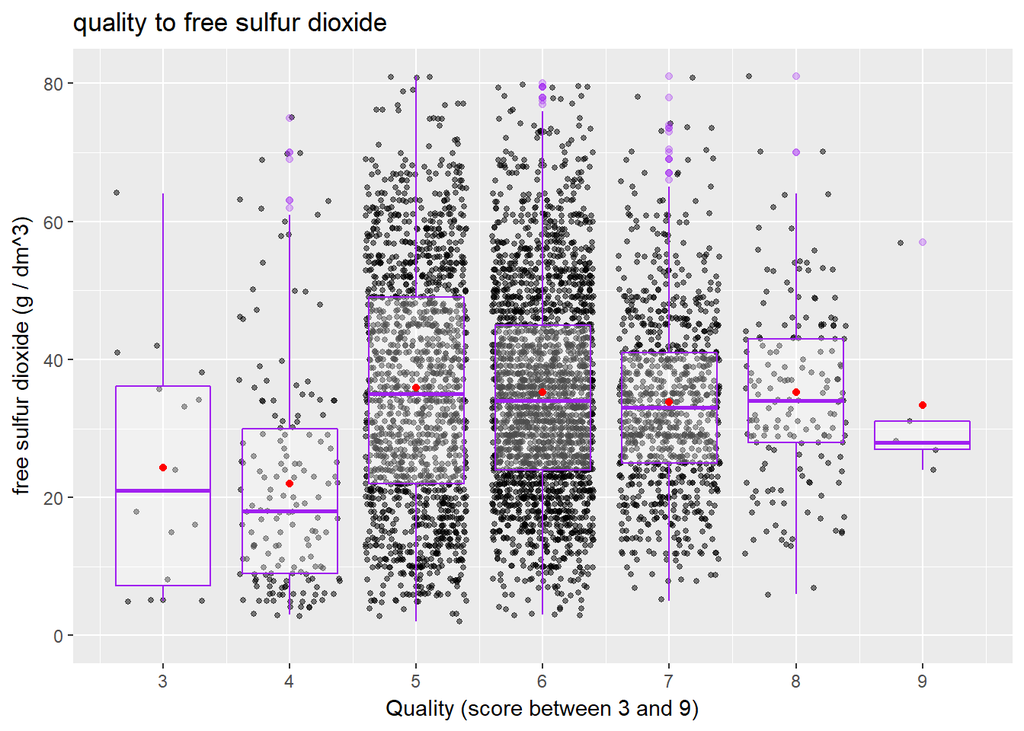

```
##
##  Pearson's product-moment correlation
##
## data:  quality and free.sulfur.dioxide
## t = 0.57085, df = 4896, p-value = 0.5681
## alternative hypothesis: true correlation is not equal to 0
## 95 percent confidence interval:
##  -0.01985292  0.03615626
## sample estimates:
##         cor
## 0.008158067
```

I removed top 1% of free sulfur results to reduce outlier effect and make the graph more readable. No clear correlation between quality and free sulfur dioxide

### quality to total sulfur dioxide

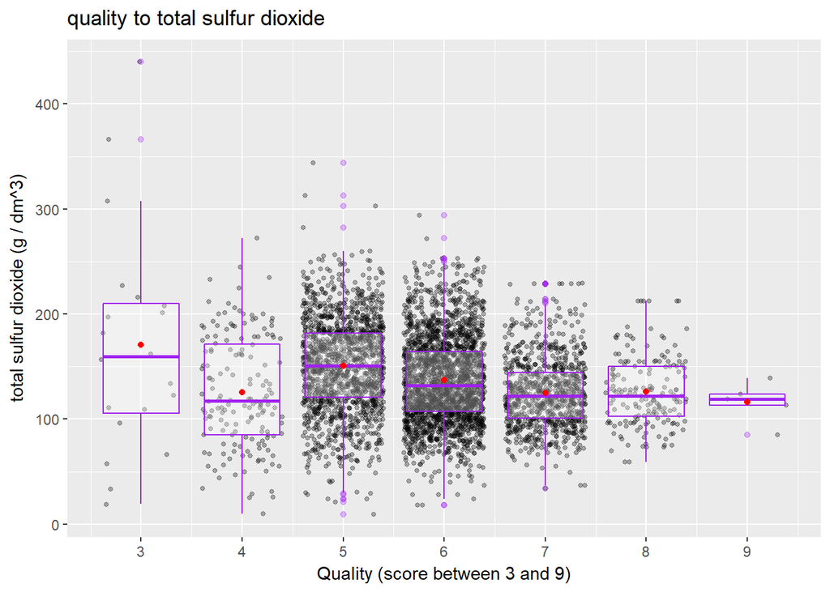

```
##
##  Pearson's product-moment correlation
##
## data:  quality and total.sulfur.dioxide
## t = -12.418, df = 4896, p-value < 2.2e-16
## alternative hypothesis: true correlation is not equal to 0
## 95 percent confidence interval:
##  -0.2017563 -0.1474524
## sample estimates:
##        cor
## -0.1747372
```

I found a weak negative correlation between quality and total sulfur dioxide without considering wines with quality value of 4 (of which there are few observations). In general quality increases as total sulfur dioxide decreases.

### quality to density

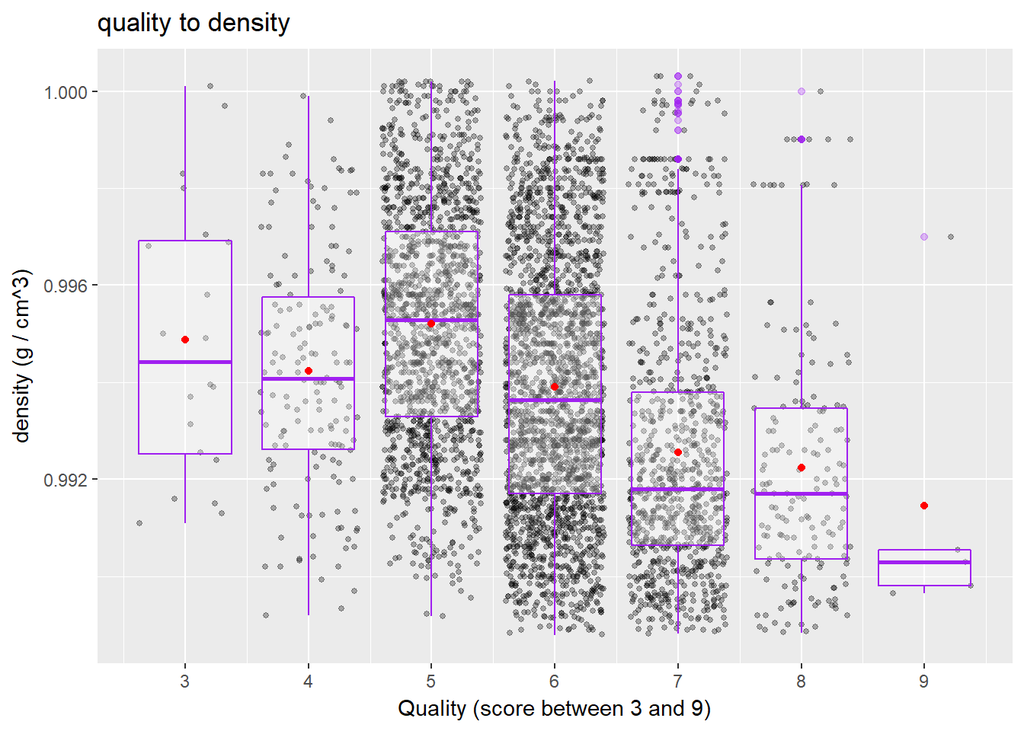

```
##
##  Pearson's product-moment correlation
##
## data:  quality and density
## t = -22.581, df = 4896, p-value < 2.2e-16
## alternative hypothesis: true correlation is not equal to 0
## 95 percent confidence interval:
##  -0.3322718 -0.2815385
## sample estimates:
##        cor
## -0.3071233
```

I removed top and buttom 1% of density results to reduce outlier effect and make the graph more readable. There is a weak negative correlation between quality and density. In general as quality increases, density decreases .

### quality to pH

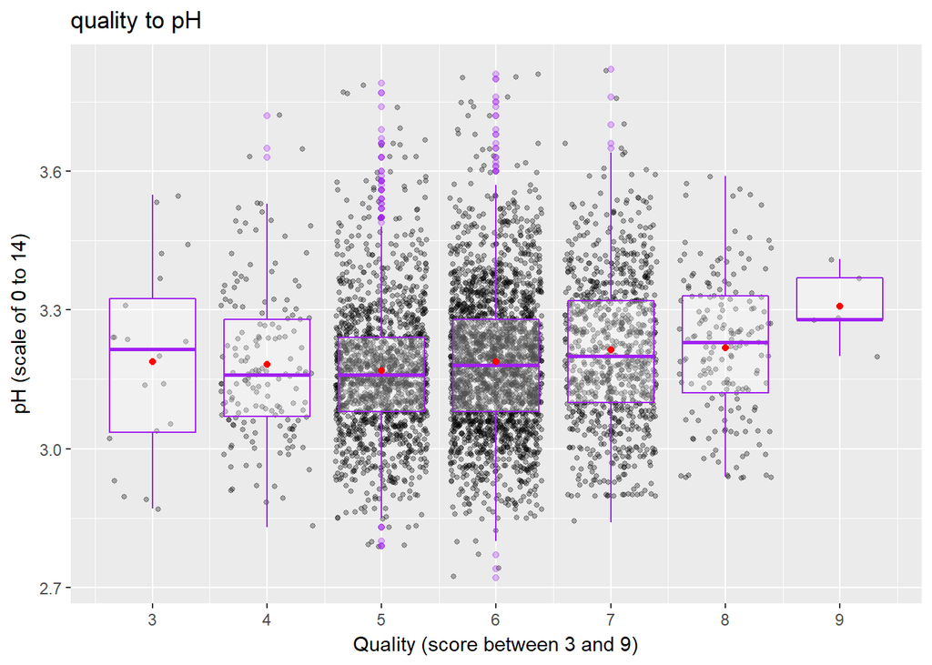

```
##
##  Pearson's product-moment correlation
##
## data:  quality and pH
## t = 6.9917, df = 4896, p-value = 3.081e-12
## alternative hypothesis: true correlation is not equal to 0
## 95 percent confidence interval:
##  0.07162022 0.12707983
## sample estimates:
##        cor
## 0.09942725
```

There is no clear correlation apparent between quality and pH.

### quality to sulphates

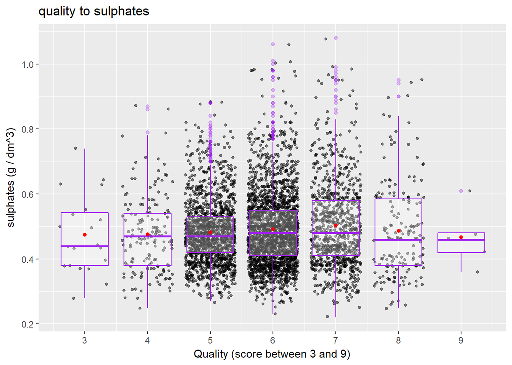

```
##
##  Pearson's product-moment correlation
##
## data:  quality and sulphates
## t = 3.7613, df = 4896, p-value = 0.000171
## alternative hypothesis: true correlation is not equal to 0
## 95 percent confidence interval:
##  0.02571007 0.08156172
## sample estimates:
##        cor
## 0.05367788
```

There seems to be no correlation between quality and sulphates.

### quality to alcohol

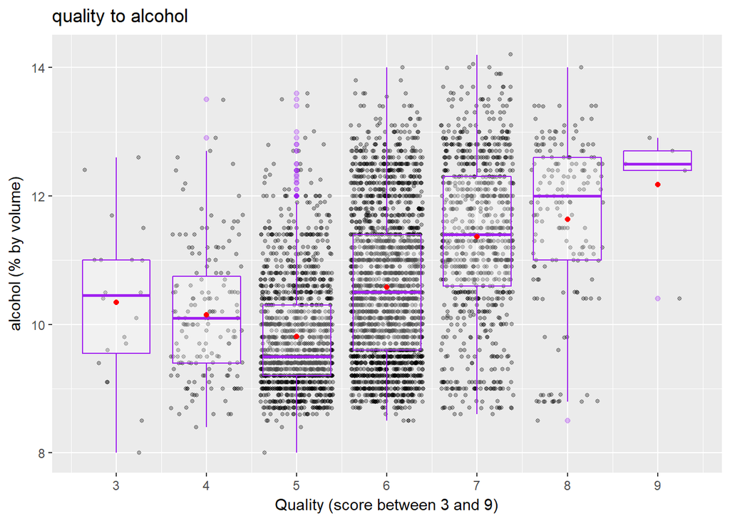

```
##
##  Pearson's product-moment correlation
##
## data:  quality and alcohol
## t = 33.858, df = 4896, p-value < 2.2e-16
## alternative hypothesis: true correlation is not equal to 0
## 95 percent confidence interval:
##  0.4126015 0.4579941
## sample estimates:
##       cor
## 0.4355747
```

There is a significant positive correlation between quality and alcohol On average as alcohol increases among the white wines, quality increases. White wines with “bad” quality (values 3 and 4) do not follow the trend.